# Airbnb data analysis of Cape Town

2020-19-07

# Executive Summary

This analysis uses Airbnb data to predict the price of an airbnb for two people for 4 nights in Cape Town.

First, the data is cleaned and the variables are put into right format.

Second, the variables of interest are examined further and informative graphs and tables are provided.

Third, the regression model for price prediction is created and examined.

What seems to predict the price are property type, room type, review ratings score, cancellation policy, how many people the property accommodates, which neighbourhood the property is in and if the property has air conditioning installed. The model has an R2 of 0.512.

# Exploratory Data Analysis

## Looking at the raw values

First, we take a look at the data.

```r
glimpse(data)
```

```
## Rows: 24,062
## Columns: 106
## $ id                                           <dbl> 3191, 15007, 15068, 15...
## $ listing_url                                  <chr> "https://www.airbnb.co...
## $ scrape_id                                    <dbl> 2.02e+13, 2.02e+13, 2....
## $ last_scraped                                 <date> 2020-06-23, 2020-06-2...
## $ name                                         <chr> "Malleson Garden Cotta...
## $ summary                                      <chr> "This is a lovely, sep...
## $ space                                        <chr> "Beautiful self cateri...
## $ description                                  <chr> "This is a lovely, sep...
## $ experiences_offered                          <chr> "none", "none", "none"...
## $ neighborhood_overview                        <chr> "Mowbray is on the Sou...
## $ notes                                        <chr> "There are pets on the...
## $ transit                                      <chr> "The train station is ...
## $ access                                       <chr> "Fully self-contained ...
```

[output cut: 93 more lines]

In the original dataset, there are 24062 observations and 106 variables. There are 41 numerical variables and 43 categorical/factor variables as seen in the table above.

## Variable Selection

In order to fit the model, the columns that are redundant, of poor data quality, or that cannot be used to explore the dependent variable are removed.

```r
#Vector of all columns we want to exclude
columns_deselect <- c(3:19, 20:22, 24:25, 27:28, 30:36, 38:39, 41:48, 58, 60, 62:63, 69:82, 84, 94:95, 96, 98, 100:105)

#Deselecting all columns we dont need
listings <- data %>%
  select(-columns_deselect)
```

## Data Wrangling

In order to run models with the data, some variables need to be modified and new variables have to be created.

First, the price variables (price, cleaning_fee, extra_people, and security_deposit) have to be changed to numeric variables, as they are now characters.

```r
# Changing price variables to numeric
listings <- listings %>%
  mutate(price = parse_number(price),
    cleaning_fee = parse_number(cleaning_fee),
    extra_people = parse_number(extra_people),
    security_deposit = parse_number(security_deposit))

# checking if the variables have been turned to numeric and if there are missing values
listings %>%
  select(price, cleaning_fee, extra_people,security_deposit) %>%
  skim()%>%
  kable()%>%
  kable_styling()
```

| skim_type | skim_variable | n_missing | complete_rate | numeric.mean | numeric.sd | numeric.p0 | numeric.p25 | numeric.p50 | numeric.p75 | numeric.p100 | numeric.hist |
| --- | --- | --- | --- | --- | --- | --- | --- | --- | --- | --- | --- |
| numeric | price | 0 | 1.000 | 2470.0 | 7527 | 0 | 659 | 1058 | 2003.0 | 300009 | ▇▁▁▁▁ |
| numeric | cleaning_fee | 7049 | 0.707 | 338.4 | 512 | 0 | 100 | 300 | 450.0 | 40000 | ▇▁▁▁▁ |
| numeric | extra_people | 0 | 1.000 | 83.8 | 220 | 0 | 0 | 0 | 96.5 | 4681 | ▇▁▁▁▁ |
| numeric | security_deposit | 8559 | 0.644 | 2770.3 | 6319 | 0 | 0 | 1478 | 3000.0 | 150000 | ▇▁▁▁▁ |

Host id is turned into a character value.

```r
#Turn IDs into string

listings <- listings %>%
  mutate(id = as.character(id),
         host_id = as.character(id))
```

A new variable called host_experience_y which tells us the number of years a host is active on Airbnb is created. We want to examine if how long the host has been active impacts how much they might charge for a listing.

```r
# final date as of 2020-09-19

# Creating a new variable call host_experience_y which tells us about the number of years the host has been active on Airbnb

listings <- listings %>%
  mutate(host_experience_y = as.numeric(ymd("2020-09-19") - host_since)/365)
```

For security_deposit, since there are 8559 missing values, the missing values will be treated as having no security deposit. The variable security_deposit is turned from a numeric to a dummy variable that evaluates to true if the listing has a security deposit and to false if not. This is done because there is a massive range of security deposits and the distribution is heavily right skewed, containing outliers and typos as well. This will help us determine whether having a security deposit influences the price.

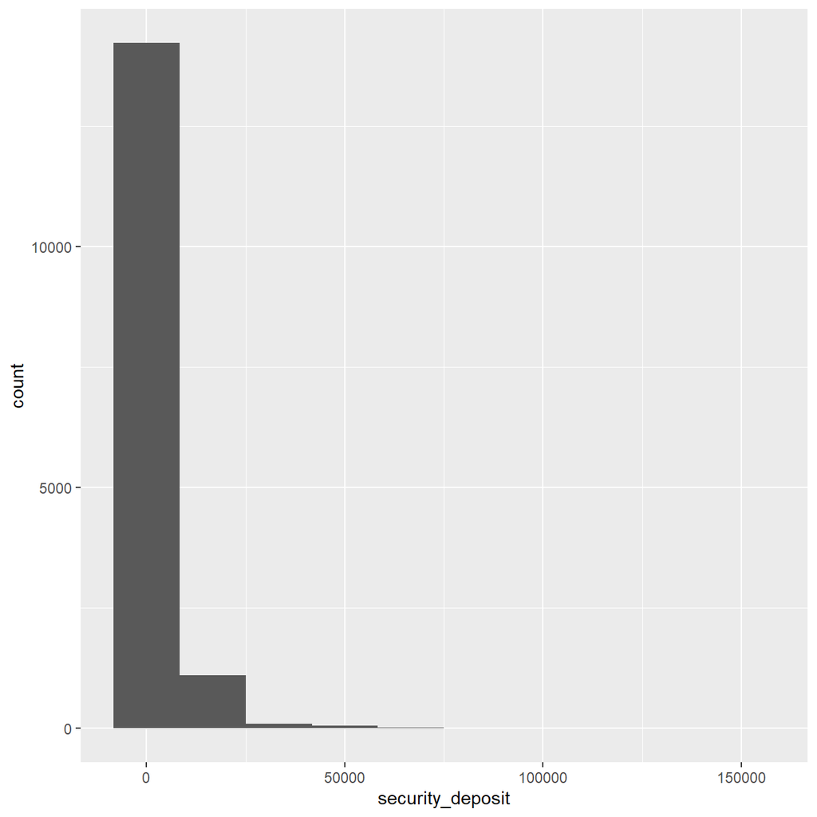

```r
ggplot(listings,aes(x=security_deposit))+
  geom_histogram(bins=10)
```

```r
#turning security_deposit into a dummy variable
listings <- listings %>%
  mutate(security_deposit = case_when(
    is.na(security_deposit) ~ 0,
    TRUE ~ security_deposit
  )) %>%
  mutate(security_deposit=case_when(
    security_deposit==0~FALSE,
    TRUE~TRUE
  ))
```

Next, we look at cancellation_policy. The cancellation policy goes from flexible to moderate in the following way:

```r
listings %>%
  count(cancellation_policy)%>%
kable()%>%
kable_styling()
```

| cancellation_policy | n |
| --- | --- |
| flexible | 7822 |
| luxury_moderate | 59 |
| luxury_super_strict_125 | 1 |
| luxury_super_strict_95 | 9 |
| moderate | 5620 |
| strict | 2 |
| strict_14_with_grace_period | 10101 |
| super_strict_30 | 397 |
| super_strict_60 | 51 |

```r
#cancellation policy is turned into a 3-category variable where it can be flexible, moderate or strict.

listings<- listings %>%
  mutate(
    cancellation_policy = case_when (cancellation_policy %in% c("flexible") ~"flexible", cancellation_policy %in% c("luxury_moderate", "moderate") ~"moderate",
cancellation_policy %in%c("luxury_super_strict_125","luxury_super_strict_95",
                          "strict","strict_14_with_grace_period","super_strict_30",
                          "super_strict_60")~"strict"),
  )
```

We want to examine whether having air conditioning affects the listing price, as we noticed that only around 30% of properties have air conditioning installed. A new variable that evaluates to TRUE if string ‘Air conditioning’ is included in amenities, and FALSE otherwise, is created.

```r
#creating the A/C variable
listings <- listings %>%
  mutate(ac=str_detect(amenities,'Air conditioning'))

proportions<-listings %>%
  group_by(ac) %>%
  summarise(count=n()) %>%
  mutate(proportion=count/sum(count))
proportions%>%
    kable()%>%
  kable_styling()
```

| ac | count | proportion |
| --- | --- | --- |
| FALSE | 17127 | 0.712 |
| TRUE | 6935 | 0.288 |

It seems that having Air conditioning in Cape Town is some sort of a luxury. Furthermore, according to website Statista, only 6% of households in South Africa have air conditioning (Global AC penetration rate by country 2016 | Statista, 2020).

We will also convert the amenities variable to be a count of the number of amenities in a certain property, rather than comma separated values.

```r
listings<- listings %>%
  mutate(total_amenities=str_count(amenities, ',')+1)
```

Additionally, neighbourhood_cleansed variable is simplified and turned into the new variable neighborhood_simplified. Cape Town is separated into over 100 Wards, which would be difficult to include in the model. Cape Town is also segmented into 24 sub-councils . Each ward is assigned to one of the 24 sub-councils following official data from capetown.gov.za. Then, based on an interview with a Cape Town local, each sub-council is a ssigned a grade corresponding to cost of living and quality of life, with the levels: best, better, good, and standard.

```r
# Cape Town is made up of 100+ diffeerent Wards.
# The column neighborhood_cleansed contains information on which Ward the listing is located in
# first assign each Ward to 1 of the 24 sub-councils that make up Cape Town, following official data from the Cape Town website
# (http://resource.capetown.gov.za/documentcentre/Documents/Maps%20and%20statistics/Population_and_Households_by_Ward_2001_and_2011.pdf)



#Vector for each sub district

SC01 <-c("Ward 23", "Ward 29",  "Ward 32",  "Ward 104")
SC02 <-c("Ward 6",  "Ward 7",   "Ward 8",   "Ward 101", "Ward 102", "Ward 111")
SC03 <-c("Ward 1",  "Ward 4",   "Ward 5",   "Ward 70",  "Ward 107", "Ward 113")
SC04 <-c("Ward 25", "Ward 26",  "Ward 27",  "Ward 28",  "Ward 30")
SC05 <-c("Ward 13", "Ward 20",  "Ward 24",  "Ward 31",  "Ward 50",  "Ward 106")
SC06 <-c("Ward 2",  "Ward 3",   "Ward 9",   "Ward 10",  "Ward 12",  "Ward 22")
SC07 <-c("Ward 21", "Ward 103", "Ward 105", "Ward 112")
SC08 <-c("Ward 83", "Ward 85",  "Ward 86",  "Ward 100")
SC09 <-c("Ward 18", "Ward 87",  "Ward 89",  "Ward 90",  "Ward 91",  "Ward 116")
SC10 <-c("Ward 92", "Ward 93",  "Ward 94",  "Ward 97",  "Ward 98",  "Ward 99")
SC11 <-c("Ward 40", "Ward 44",  "Ward 46",  "Ward 47")
SC12 <-c("Ward 78", "Ward 79",  "Ward 81",  "Ward 82")
SC13 <-c("Ward 34", "Ward 35",  "Ward 36",  "Ward 80",  "Ward 88")
SC14 <-c("Ward 37", "Ward 38",  "Ward 39",  "Ward 41",  "Ward 42",  "Ward 45")
SC15 <-c("Ward 51", "Ward 52",  "Ward 53",  "Ward 55",  "Ward 56")
SC16 <-c("Ward 54", "Ward 57",  "Ward 74",  "Ward 77",  "Ward 115")
SC17 <-c("Ward 48", "Ward 49",  "Ward 60")
SC18 <-c("Ward 63", "Ward 65",  "Ward 66",  "Ward 67",  "Ward 68",  "Ward 110")
SC19 <-c("Ward 61", "Ward 64",  "Ward 69")
SC20 <-c("Ward 58", "Ward 59",  "Ward 62",  "Ward 71",  "Ward 72",  "Ward 73")
SC21 <-c("Ward 11", "Ward 19",  "Ward 108")
SC22 <-c("Ward 14", "Ward 16",  "Ward 17",  "Ward 114")
SC23 <-c("Ward 33", "Ward 43",  "Ward 75",  "Ward 76")
SC24 <-c("Ward 15", "Ward 84",  "Ward 95",  "Ward 96",  "Ward 109")
```

```r
# Based on an interview with a local, assign a grade corresponding to quality of life to  24 sub-councils

# vector for living quality

Best <-c(SC16, SC19, SC20)
Better <-c(SC01, SC08, SC15, SC17)
Good <-c(SC02, SC03, SC04, SC05, SC06, SC07, SC08, SC15, SC21, SC22, SC23, SC24)
Standard <-c(SC09, SC10, SC11, SC12, SC13, SC14, SC17, SC18)
```

```r
# Next, create two new variables: "sub_council", containing the sub council for each listing and "neighborhood_simplified", classifying the location of the listing to either standard, good, better or best.
#assigning sub council

listings <- listings %>%
  mutate(sub_council = case_when(neighbourhood_cleansed %in% SC01 ~ "SC01",
                                 neighbourhood_cleansed %in% SC02 ~ "SC02",
                                 neighbourhood_cleansed %in% SC03 ~ "SC03",
                                 neighbourhood_cleansed %in% SC04 ~ "SC04",
                                 neighbourhood_cleansed %in% SC05 ~ "SC05",
                                 neighbourhood_cleansed %in% SC06 ~ "SC06",
                                 neighbourhood_cleansed %in% SC07 ~ "SC07",
                                 neighbourhood_cleansed %in% SC08 ~ "SC08",
                                 neighbourhood_cleansed %in% SC09 ~ "SC09",
                                 neighbourhood_cleansed %in% SC10 ~ "SC10",
                                 neighbourhood_cleansed %in% SC11 ~ "SC11",
                                 neighbourhood_cleansed %in% SC12 ~ "SC12",
                                 neighbourhood_cleansed %in% SC13 ~ "SC13",
                                 neighbourhood_cleansed %in% SC14 ~ "SC14",
                                 neighbourhood_cleansed %in% SC15 ~ "SC15",
                                 neighbourhood_cleansed %in% SC16 ~ "SC16",
                                 neighbourhood_cleansed %in% SC17 ~ "SC17",
                                 neighbourhood_cleansed %in% SC18 ~ "SC18",
                                 neighbourhood_cleansed %in% SC19 ~ "SC19",
                                 neighbourhood_cleansed %in% SC20 ~ "SC20",
                                 neighbourhood_cleansed %in% SC21 ~ "SC21",
                                 neighbourhood_cleansed %in% SC22 ~ "SC22",
                                 neighbourhood_cleansed %in% SC23 ~ "SC23",
                                 neighbourhood_cleansed %in% SC24 ~ "SC24"
                                 ))
```

```r
# Assigning neighbourhood simplified

listings <- listings %>%
  mutate(neighbourhood_simplified = case_when(neighbourhood_cleansed %in% Best ~ "best",
                                              neighbourhood_cleansed %in% Better ~ "better",
                                              neighbourhood_cleansed %in% Good ~ "good",
                                              neighbourhood_cleansed %in% Standard ~ "standard"))
```

Now we take a look at the minimum_nights variable and filter only to include listings where the minimum number of nights is less than or equal to 4.

```r
#To check the 5 most common values for the variable `minimum_nights`
listings%>%
  count(minimum_nights)%>%
  arrange(desc(n))%>%
  kable()%>%
  kable_styling()
```

| minimum_nights | n |
| --- | --- |
| 2 | 7436 |
| 1 | 6894 |
| 3 | 3527 |
| 7 | 1614 |
| 5 | 1489 |
| 4 | 1098 |
| 10 | 508 |
| 14 | 337 |
| 20 | 252 |
| 6 | 244 |
| 30 | 182 |
| 8 | 62 |
| 90 | 59 |
| 28 | 50 |
| 12 | 47 |
| 15 | 36 |
| 21 | 35 |
| 60 | 33 |
| 180 | 27 |
| 9 | 17 |
| 13 | 12 |
| 31 | 11 |
| 25 | 9 |
| 100 | 8 |
| 120 | 7 |
| 29 | 6 |
| 365 | 6 |
| 11 | 5 |
| 18 | 3 |
| 27 | 3 |
| 45 | 3 |
| 93 | 3 |
| 150 | 3 |
| 360 | 3 |
| 16 | 2 |
| 19 | 2 |
| 22 | 2 |
| 24 | 2 |
| 32 | 2 |
| 95 | 2 |
| 168 | 2 |
| 183 | 2 |
| 185 | 2 |
| 210 | 2 |
| 26 | 1 |
| 33 | 1 |
| 40 | 1 |
| 42 | 1 |
| 89 | 1 |
| 91 | 1 |
| 94 | 1 |
| 124 | 1 |
| 182 | 1 |
| 186 | 1 |
| 240 | 1 |
| 300 | 1 |
| 1125 | 1 |

```r
#To filter the variable `minimum_nights`
listings <- listings %>%
  filter(minimum_nights<= 4)
```

The top 5 most common values for minimum nights are: 2, 1, 3, 7 and 5, other seem to be a week or less, which means most listings are probably used for tourism. However, some of the less common values also offer minimum stays of 30 or 365 days which demonstrates that some listings are to be rented for a month or year.

## Handling NAs

```r
listings%>%
skim(cleaning_fee)%>%
  kable()%>%
  kable_styling()
```

| skim_type | skim_variable | n_missing | complete_rate | numeric.mean | numeric.sd | numeric.p0 | numeric.p25 | numeric.p50 | numeric.p75 | numeric.p100 | numeric.hist |
| --- | --- | --- | --- | --- | --- | --- | --- | --- | --- | --- | --- |
| numeric | cleaning_fee | 5253 | 0.723 | 303 | 498 | 0 | 80 | 250 | 432 | 40000 | ▇▁▁▁▁ |

```r
listings <- listings %>%
  mutate(cleaning_fee = case_when(
    is.na(cleaning_fee) ~ 0,
    TRUE ~ cleaning_fee
  ))
```

## Creating the dependent variable: price_4_nights

```r
listings <- listings%>%
  filter(guests_included<=2)%>%
  mutate(
    extra_charge_pp= case_when(guests_included==2 ~ 0, guests_included ==1 ~ extra_people),
    price_4_nights= price*4 + extra_charge_pp*4 + cleaning_fee
  )
```

## Computing summary statistics and visualizing the distribution of the variables of interest

We want to look at how the variables are distributed, and how strong the correlation between explanatory variables is.

First, we will examine the host_experience_y variable that was created, which demonstrates how long a host has been listed on Airbnb.

```r
#Descriptive Analysis

kable(favstats(~host_experience_y, data=listings))%>%
  kable_styling()
```

|  | min | Q1 | median | Q3 | max | mean | sd | n | missing |
| --- | --- | --- | --- | --- | --- | --- | --- | --- | --- |
|  | 0.258 | 2.79 | 4.42 | 5.59 | 11.9 | 4.29 | 2.05 | 17299 | 2 |

```r
skim(listings$host_experience_y)%>%
  kable()%>%
  kable_styling()
```

| skim_type | skim_variable | n_missing | complete_rate | numeric.mean | numeric.sd | numeric.p0 | numeric.p25 | numeric.p50 | numeric.p75 | numeric.p100 | numeric.hist |
| --- | --- | --- | --- | --- | --- | --- | --- | --- | --- | --- | --- |
| numeric | data | 2 | 1 | 4.29 | 2.05 | 0.258 | 2.79 | 4.42 | 5.59 | 11.9 | ▅▇▆▂▁ |

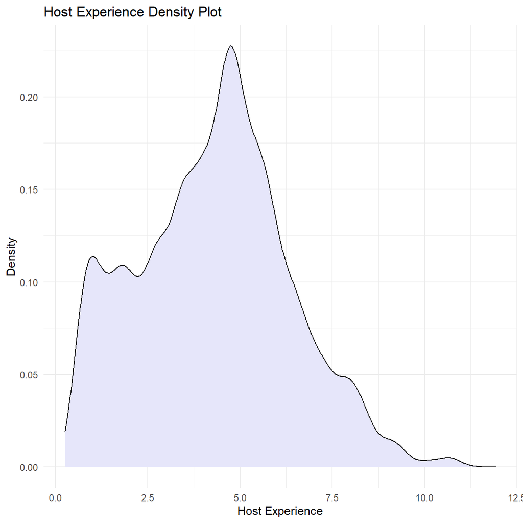

```r
ggplot(listings, aes(x=host_experience_y)) +
  geom_density(fill = "lavender") +
  labs(x = "Host Experience", y="Density", title= "Host Experience Density Plot") +
  theme_minimal()
```

Next, we will look at host_is_superhost. We might want to use this in our model to examine whether superhosts tend to charge a premium.

```r
skim(listings$host_is_superhost)%>%
  kable()%>%
  kable_styling()
```

| skim_type | skim_variable | n_missing | complete_rate | logical.mean | logical.count |
| --- | --- | --- | --- | --- | --- |
| logical | data | 2 | 1 | 0.247 | FAL: 13029, TRU: 4270 |

```r
listings %>%
  count(host_is_superhost)%>%
  kable()%>%
  kable_styling()
```

| host_is_superhost | n |
| --- | --- |
| FALSE | 13029 |
| TRUE | 4270 |
| NA | 2 |

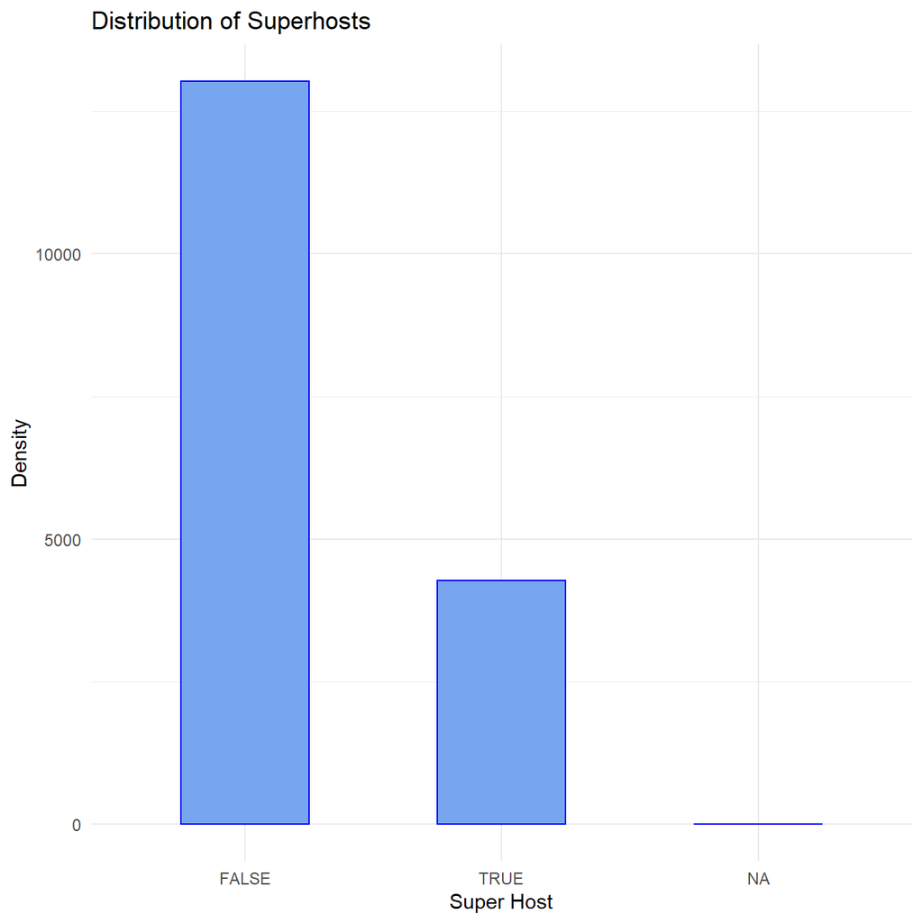

```r
ggplot(listings, aes(x = host_is_superhost)) +
  geom_bar(width = 0.5, color = "blue", fill = "#77a5f0") +
  labs(x = "Super Host", y="Density", title= "Distribution of Superhosts") +
  theme_minimal()
```

Based on the data above, roughly 1/4 of all hosts in Cape Town are super hosts.

Now, we look at number_of_reviews, which represents the total number of reviews on a particular listing.

```r
listings%>%
  skim(number_of_reviews)%>%
  kable()%>%
  kable_styling()
```

| skim_type | skim_variable | n_missing | complete_rate | numeric.mean | numeric.sd | numeric.p0 | numeric.p25 | numeric.p50 | numeric.p75 | numeric.p100 | numeric.hist |
| --- | --- | --- | --- | --- | --- | --- | --- | --- | --- | --- | --- |
| numeric | number_of_reviews | 0 | 1 | 15.9 | 30.7 | 0 | 0 | 3 | 16 | 425 | ▇▁▁▁▁ |

```r
kable(favstats(~number_of_reviews, data=listings))%>%
  kable_styling()
```

|  | min | Q1 | median | Q3 | max | mean | sd | n | missing |
| --- | --- | --- | --- | --- | --- | --- | --- | --- | --- |
|  | 0 | 0 | 3 | 16 | 425 | 15.9 | 30.7 | 17301 | 0 |

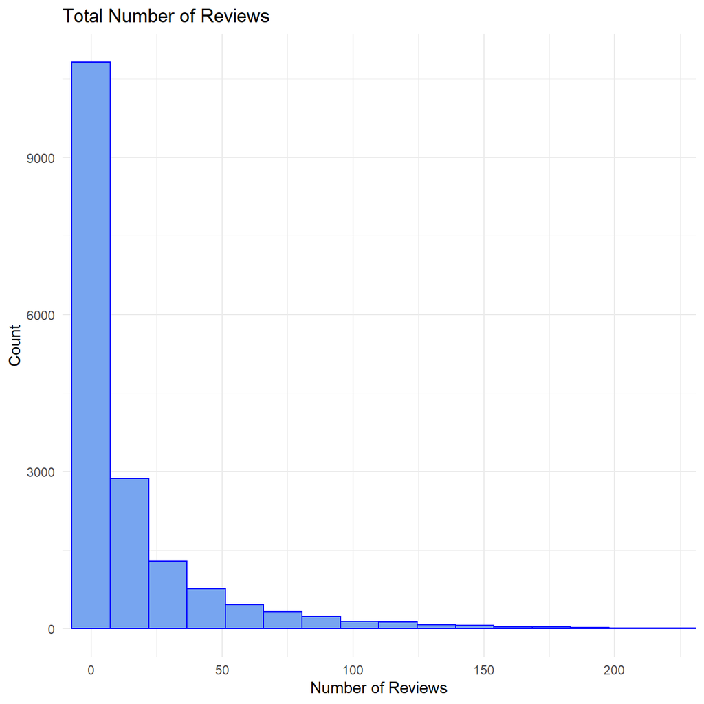

```r
listings%>%
  ggplot(aes(x=number_of_reviews))+
  geom_histogram(aes(x = number_of_reviews), color = "blue", fill = "#77a5f0") +
  labs(x = "Number of Reviews", y="Count", title= "Total Number of Reviews") +
  ggtitle("Total Number of Reviews") +
  coord_cartesian(xlim = c(0, 220)) +
  theme_minimal()
```

Now we’ll look at the review_scores_rating variable, as we want to examine whether listings with higher reviews charge a premium.

```r
  kable(favstats(~review_scores_rating, data=listings))%>%
  kable_styling()
```

|  | min | Q1 | median | Q3 | max | mean | sd | n | missing |
| --- | --- | --- | --- | --- | --- | --- | --- | --- | --- |
|  | 20 | 93 | 97 | 100 | 100 | 94.5 | 8.99 | 12395 | 4906 |

Now let’s visualize the distribution:

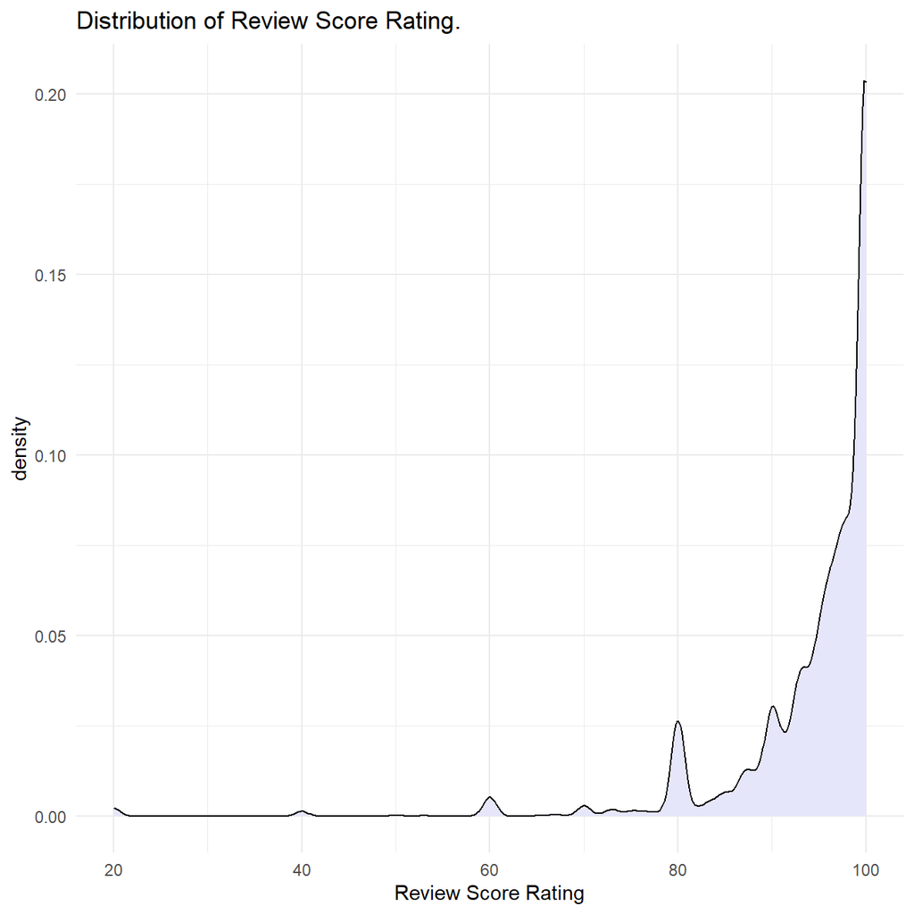

```r
listings%>%
  ggplot(aes(x=review_scores_rating))+
  geom_density(fill="lavender") +
  labs(x = "Review Score Rating") +
  ggtitle("Distribution of Review Score Rating.") +
  theme_minimal()
```

The distribution is heavily left-skewed with most of the ratings in the 90’s. There is a small second peak at 80.

The following variables are reviews for individual categories. They all exhibit very similar distributions to review_scores_rating and between each-other. They therefore won’t be added to the models.

```r
accuracy<-listings%>%
  ggplot(aes(x=review_scores_accuracy)) +
  geom_bar(width = 0.5, color = "blue", fill="#77a5f0") +
  labs(x = "Review Score Accuracy") +
  ggtitle("Accuracy") +
  theme_minimal()
```

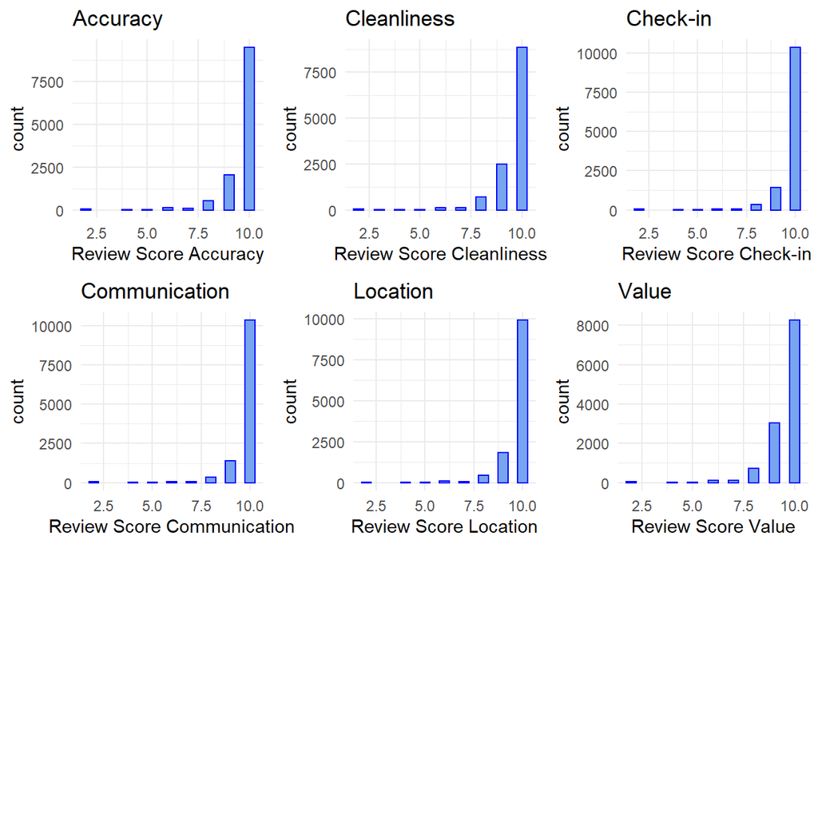

```r
library(gridExtra)
grid.arrange(accuracy, cleanliness, check_in, communication, location, value, nrow = 3, ncol = 3)
```

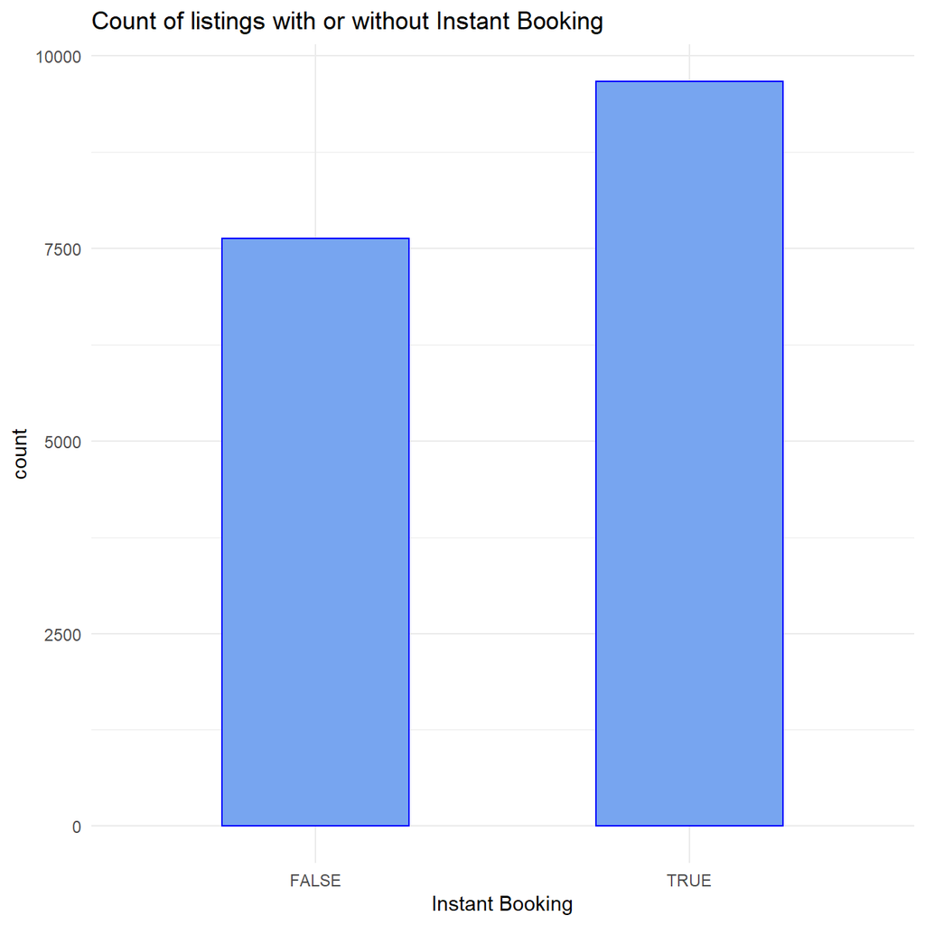

```r
ggplot(listings, aes(x = instant_bookable)) +
  geom_bar(width = 0.5, color = "blue", fill = "#77a5f0") +
  labs(x = "Instant Booking") +
  ggtitle("Count of listings with or without Instant Booking") +
  theme_minimal() +
  NULL
```

We also want to explore the property_type variable.

```r
#To check the top 4 categories of property type in Cape Town
listings %>%
count(property_type) %>%
arrange(desc(n))%>%
  kable()%>%
  kable_styling()
```

| property_type | n |
| --- | --- |
| Apartment | 7500 |
| House | 3917 |
| Guest suite | 1357 |
| Guesthouse | 936 |
| Bed and breakfast | 600 |
| Villa | 489 |
| Serviced apartment | 410 |
| Condominium | 408 |
| Cottage | 355 |
| Townhouse | 355 |
| Loft | 270 |
| Boutique hotel | 162 |
| Bungalow | 93 |
| Hostel | 90 |
| Other | 81 |
| Farm stay | 50 |
| Chalet | 44 |
| Tiny house | 32 |
| Aparthotel | 29 |
| Hotel | 26 |
| Cabin | 25 |
| Nature lodge | 14 |
| Earth house | 11 |
| Camper/RV | 9 |
| Boat | 6 |
| Dorm | 5 |
| Resort | 5 |
| Tipi | 4 |
| Barn | 2 |
| Casa particular (Cuba) | 2 |
| Castle | 2 |
| Hut | 2 |
| Lighthouse | 2 |
| Treehouse | 2 |
| Bus | 1 |
| Cave | 1 |
| Dome house | 1 |
| Heritage hotel (India) | 1 |
| Tent | 1 |
| Vacation home | 1 |

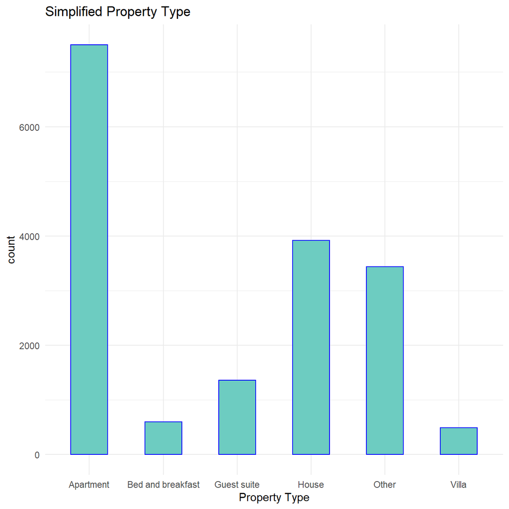

```r
#To simplify the `property_type` variable into 5 categories, Mutate others to gather the other property type with small values
listings <- listings %>%
  mutate(prop_type_simplified = case_when(
    property_type %in% c("Apartment","House","Guest suite","Villa","Guest House","Bed and breakfast") ~ property_type,
    TRUE ~ "Other"
  ))

listings %>%
  ggplot(aes(x=prop_type_simplified)) +
  labs(x = "Property Type") +
  ggtitle("Simplified Property Type") +
  geom_bar(width = 0.5, color = "blue", fill = "#6dccc1") +
  theme_minimal()
```

```r
View(listings)
```

Finally, we examine the distribution of listings based on quality of life in the area that they are located in.

```r
#count by neighborhood
listings %>%
  count(neighbourhood_simplified) %>%
  arrange(desc(n))%>%
  kable()%>%
  kable_styling()
```

| neighbourhood_simplified | n |
| --- | --- |
| best | 11457 |
| good | 3187 |
| better | 2470 |
| standard | 187 |

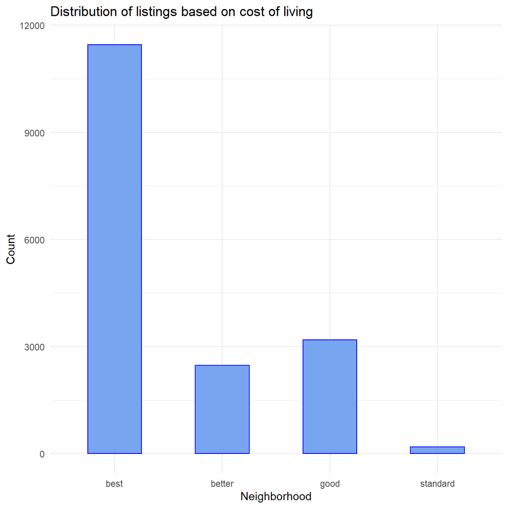

```r
ggplot(listings, aes(x = neighbourhood_simplified)) +
  geom_bar(width = 0.5, color = "blue", fill = "#77a5f0") +
  labs(x = "Neighborhood", y="Count", title="Distribution of listings based on cost of living") +
  theme_minimal()
```

The majority of the Airbnb listings seem to be located in Wards that are classified as “best” with regards to location. These are likely to be popular destinations for tourists.

## Examining correlations between variables

Now we will take a look at some of the relationships between the explanatory variables that might be included into the model.

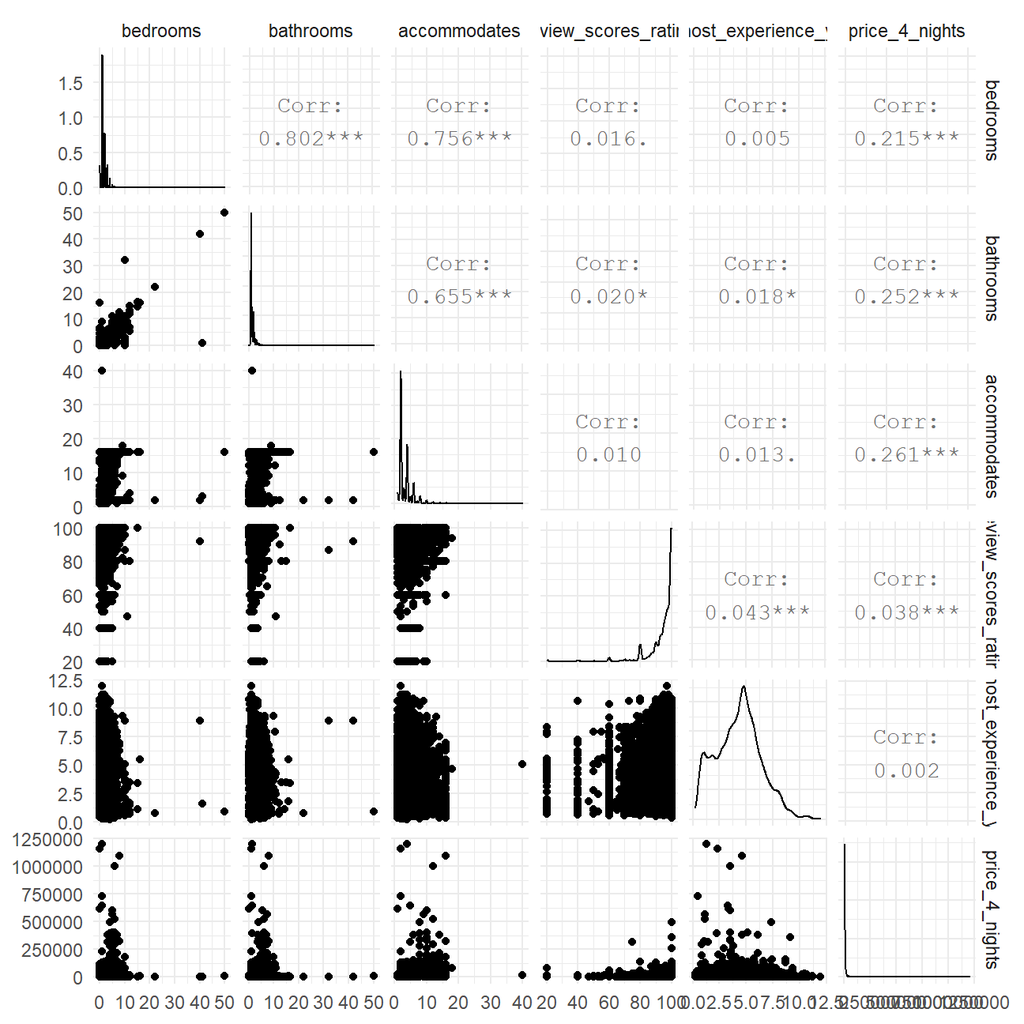

```r
# To see the correlations between variables
listings%>%
  select(bedrooms, bathrooms, accommodates, review_scores_rating, host_experience_y, price_4_nights) %>%
  ggpairs(alpha=0.4) +
  theme_minimal()
```

Based on the correlation matrix above, it looks like the variables bathroom,bedrooms, and accommodates are highly correlated. This is expected since the more people a property accommodates the more bathrooms and bedrooms it will have. Therefore, only accommodates will be plugged into the model.

Now, we will look at the relationship between property type and price.

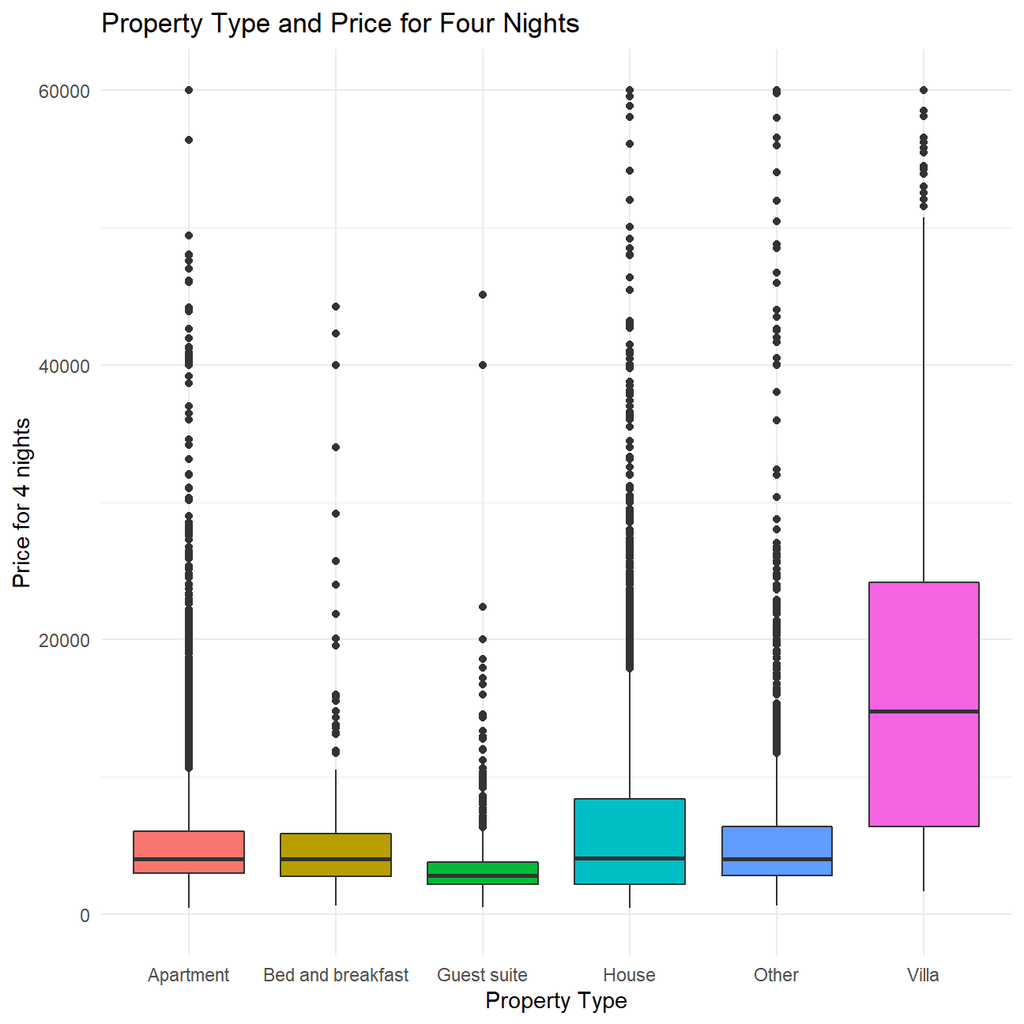

```r
listings %>%
  ggplot(aes(x=prop_type_simplified, y= price_4_nights)) +
           geom_boxplot(aes(fill=prop_type_simplified), show.legend=FALSE)+
           theme_minimal()+
          labs(x="Property Type", title="Property Type and Price for Four Nights")+
          scale_y_continuous(name="Price for 4 nights", limits = c(0,60000))
```

Based on the plot, Villa and House have a higher price as compared to other property types.

We will also examine neighborhoods in the plot below.

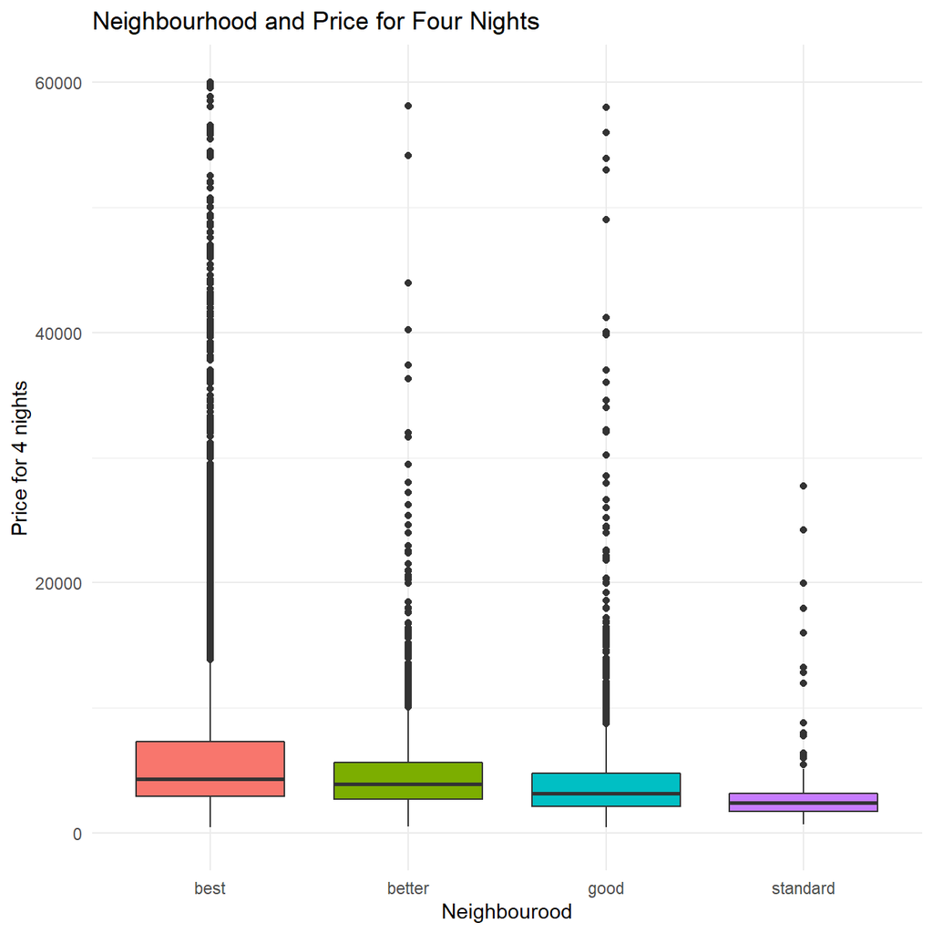

```r
listings %>%
  ggplot(aes(x=neighbourhood_simplified, y= price_4_nights)) +
           geom_boxplot(aes(fill=neighbourhood_simplified), show.legend=FALSE)+
           theme_minimal()+
          labs(x="Neighbourood", title="Neighbourhood and Price for Four Nights")+
          scale_y_continuous(name="Price for 4 nights", limits = c(0,60000))
```

As expected, it seems like listings in the “best” neighbourhoods are most expensive, while those in “standard” are cheapest. We will test whether this effect is significant later in the model.

We will also look at host_is_superhost.

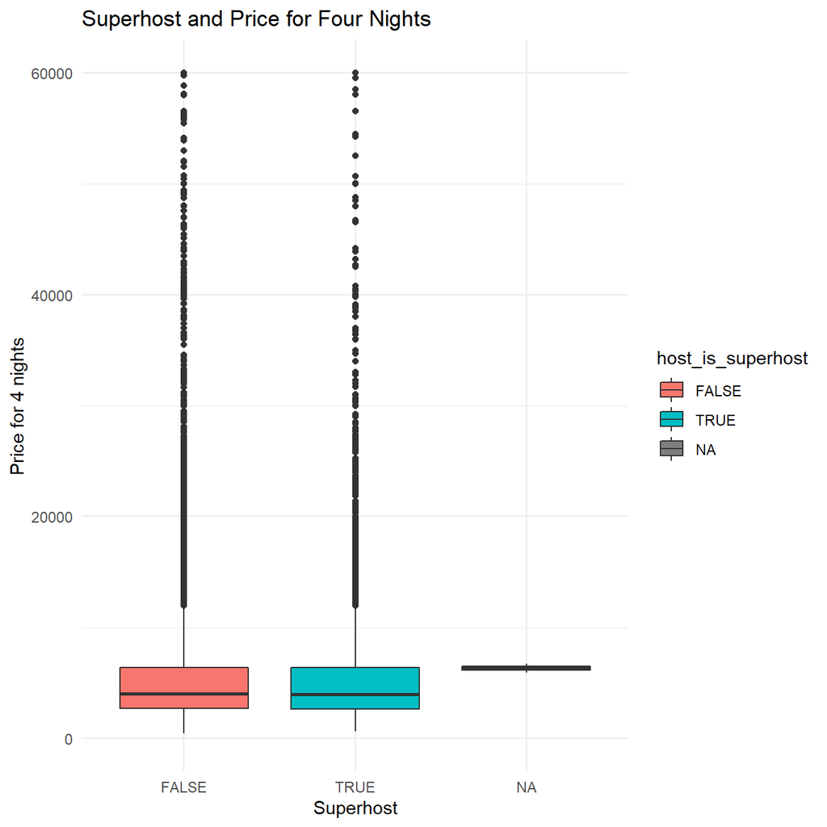

```r
listings %>%
  ggplot(aes(x=host_is_superhost, y= price_4_nights)) +
           geom_boxplot(aes(fill=host_is_superhost, show.legend=FALSE))+
           theme_minimal()+
          labs(x="Superhost", title="Superhost and Price for Four Nights")+
          scale_y_continuous(name="Price for 4 nights", limits = c(0,60000))
```

There does not seem to be a large difference between whether a host is a superhost and the price of the listing. We will also take a look at cancellation_policy.

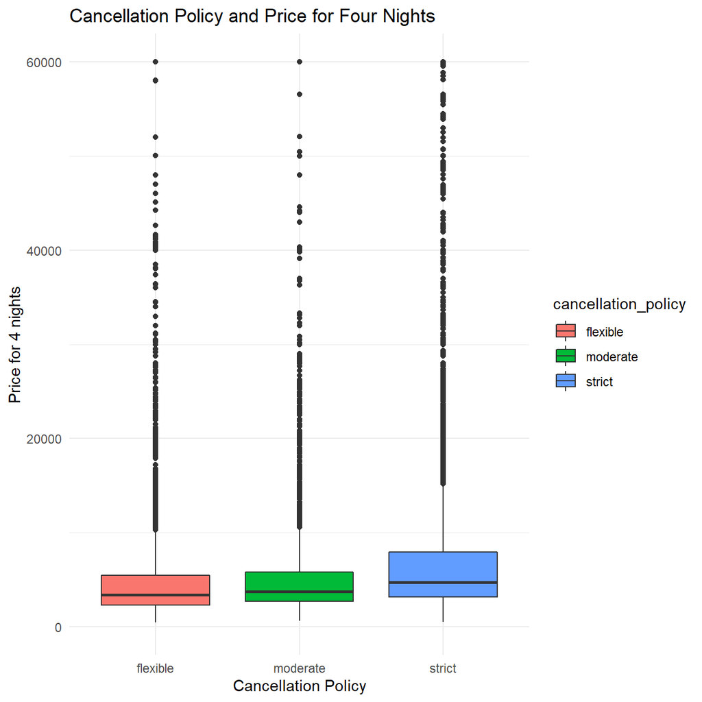

```r
listings %>%
  ggplot(aes(x=cancellation_policy, y= price_4_nights)) +
           geom_boxplot(aes(fill=cancellation_policy, show.legend=FALSE))+
           theme_minimal()+
          labs(x="Cancellation Policy", title="Cancellation Policy and Price for Four Nights")+
          scale_y_continuous(name="Price for 4 nights", limits = c(0,60000))
```

It seems like listings with stricter policies are slightly more expensive, which could be because they are more desirable listings.

Finally, we will examine the air conditioning variable.

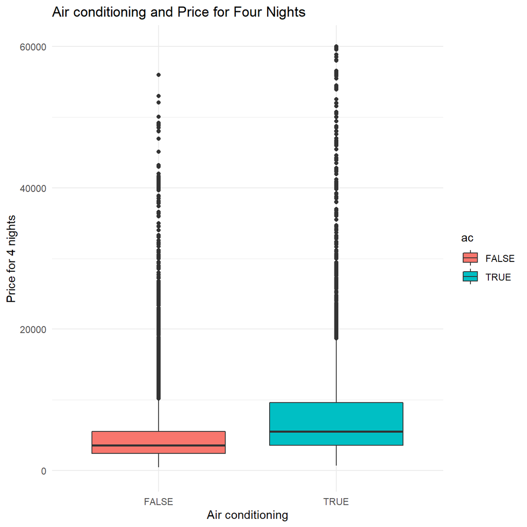

```r
listings %>%
  ggplot(aes(x=ac, y= price_4_nights)) +
           geom_boxplot(aes(fill=ac, show.legend=FALSE))+
           theme_minimal()+
          labs(x="Air conditioning", title="Air conditioning and Price for Four Nights")+
          scale_y_continuous(name="Price for 4 nights", limits = c(0,60000))
```

# Mapping

Visualising the map of listings in Cape Town

```r
#creating the map
leaflet(data = filter(listings, minimum_nights <= 4,accommodates>=2)) %>%
  addProviderTiles("OpenStreetMap.Mapnik") %>%
  addCircleMarkers(lng = ~longitude,
                   lat = ~latitude,
                   radius = 1,
                   fillColor = "blue",
                   fillOpacity = 0.4,
                   popup = ~listing_url,
                   label = ~property_type)
```

[interactive chart not shown]

# Regression Analysis

## Visualizing the distribution of price_4_nights

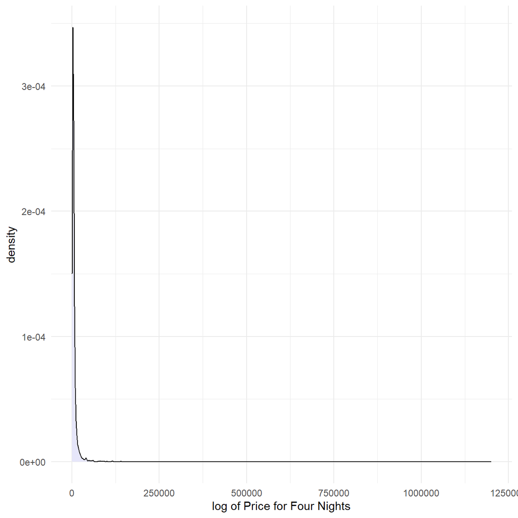

```r
#density plot price_4_nights
ggplot(data=listings, aes(x=price_4_nights)) +
  geom_density(fill = "lavender") +
  labs(x="log of Price for Four Nights") +
  theme_minimal()
```

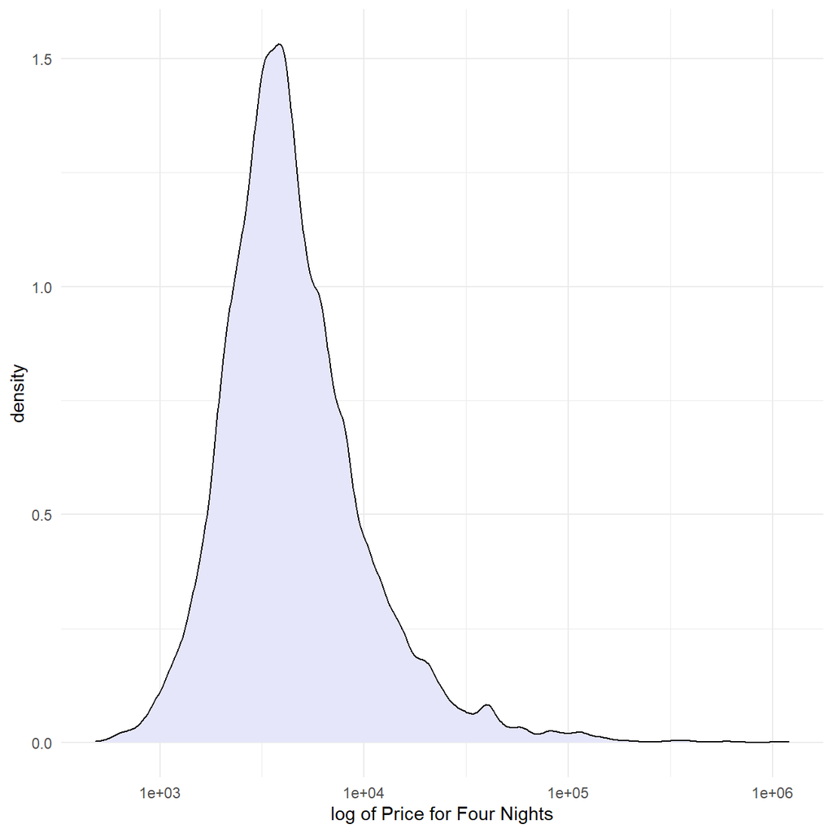

```r
#density plot log
ggplot(data=listings, aes(x=price_4_nights)) +
  scale_x_log10()+geom_density(fill = "lavender") +
  labs(x="log of Price for Four Nights") +
  theme_minimal()
```

Price_4_nights is very heavily positively skewed. Log (price_4_nights), on the other hand, is approximately normally distributed. Hence, log (price_4_nights) is a better candidate for further modeling.

Next, we fit a regression model with prop_type_simplified.

```r
# ***** Fit linear regression models: First, just the mean
model0 <- lm(log (price_4_nights) ~ 1, data= listings)

model0 %>%
  broom::tidy(conf.int=TRUE)
```

| term | estimate | std.error | statistic | p.value | conf.low | conf.high |
| --- | --- | --- | --- | --- | --- | --- |
| (Intercept) | 8.41 | 0.0061 | 1.38e+03 | 0 | 8.4 | 8.43 |

```r
model0 %>%
  broom::glance()
```

| r.squared | adj.r.squared | sigma | statistic | p.value | df | logLik | AIC | BIC | deviance | df.residual | nobs |
| --- | --- | --- | --- | --- | --- | --- | --- | --- | --- | --- | --- |
| 0 | 0 | 0.803 |  |  |  | -2.08e+04 | 4.15e+04 | 4.15e+04 | 1.12e+04 | 17300 | 17301 |

```r
# ***** Fit linear regression models: criminals on 3 explanatory variables.
model1 <- lm(log (price_4_nights) ~ prop_type_simplified, data= listings)

model1 %>%
  broom::tidy(conf.int=TRUE)%>%
  kable()%>%
  kable_styling()
```

| term | estimate | std.error | statistic | p.value | conf.low | conf.high |
| --- | --- | --- | --- | --- | --- | --- |
| (Intercept) | 8.391 | 0.009 | 960.350 | 0.000 | 8.374 | 8.408 |
| prop_type_simplifiedBed and breakfast | -0.058 | 0.032 | -1.820 | 0.069 | -0.121 | 0.005 |
| prop_type_simplifiedGuest suite | -0.393 | 0.022 | -17.590 | 0.000 | -0.436 | -0.349 |
| prop_type_simplifiedHouse | 0.053 | 0.015 | 3.558 | 0.000 | 0.024 | 0.082 |
| prop_type_simplifiedOther | 0.014 | 0.016 | 0.916 | 0.360 | -0.016 | 0.045 |
| prop_type_simplifiedVilla | 1.455 | 0.035 | 41.203 | 0.000 | 1.386 | 1.524 |

```r
model1 %>%
  broom::glance()%>%
 kable()%>%
  kable_styling()
```

| r.squared | adj.r.squared | sigma | statistic | p.value | df | logLik | AIC | BIC | deviance | df.residual | nobs |
| --- | --- | --- | --- | --- | --- | --- | --- | --- | --- | --- | --- |
| 0.112 | 0.112 | 0.757 | 436 | 0 | 5 | -19723 | 39459 | 39514 | 9903 | 17295 | 17301 |

### Model 2: adding room_type

We want to determine if room_type is a significant predictor of the cost for 4 nights, while controlling for property_type.

```r
# ***** Fit linear regression models: criminals on 4 explanatory variables.
model2 <- lm(log (price_4_nights) ~ prop_type_simplified+room_type, data= listings)

model2 %>%
  broom::tidy(conf.int=TRUE)%>%
   kable()%>%
  kable_styling()
```

| term | estimate | std.error | statistic | p.value | conf.low | conf.high |
| --- | --- | --- | --- | --- | --- | --- |
| (Intercept) | 8.467 | 0.008 | 1023.6 | 0.000 | 8.451 | 8.483 |
| prop_type_simplifiedBed and breakfast | 0.360 | 0.034 | 10.7 | 0.000 | 0.294 | 0.426 |
| prop_type_simplifiedGuest suite | -0.272 | 0.021 | -13.0 | 0.000 | -0.313 | -0.231 |
| prop_type_simplifiedHouse | 0.291 | 0.015 | 19.8 | 0.000 | 0.262 | 0.319 |
| prop_type_simplifiedOther | 0.176 | 0.015 | 11.7 | 0.000 | 0.146 | 0.206 |
| prop_type_simplifiedVilla | 1.523 | 0.033 | 46.3 | 0.000 | 1.458 | 1.587 |
| room_typeHotel room | -0.084 | 0.040 | -2.1 | 0.036 | -0.162 | -0.006 |
| room_typePrivate room | -0.649 | 0.013 | -49.3 | 0.000 | -0.675 | -0.624 |
| room_typeShared room | -1.124 | 0.064 | -17.6 | 0.000 | -1.248 | -0.999 |

```r
model2 %>%
  broom::glance()%>%
   kable()%>%
  kable_styling()
```

| r.squared | adj.r.squared | sigma | statistic | p.value | df | logLik | AIC | BIC | deviance | df.residual | nobs |
| --- | --- | --- | --- | --- | --- | --- | --- | --- | --- | --- | --- |
| 0.231 | 0.231 | 0.704 | 649 | 0 | 8 | -18479 | 36978 | 37055 | 8577 | 17292 | 17301 |

All else equal, room_typePrivate room and room_typeShared room are significant predictors of the cost for 4 night as it has T-statistics >2 and p-value <0.05.

Now we will explore further variables.

### Model 3: Adding review_scores_rating

```r
model3 <- lm(log (price_4_nights) ~ prop_type_simplified + review_scores_rating + room_type, data= listings)

model3 %>%
  broom::tidy(conf.int=TRUE)%>%
  kable()%>%
  kable_styling()
```

| term | estimate | std.error | statistic | p.value | conf.low | conf.high |
| --- | --- | --- | --- | --- | --- | --- |
| (Intercept) | 8.086 | 0.059 | 135.938 | 0.00 | 7.970 | 8.203 |
| prop_type_simplifiedBed and breakfast | 0.371 | 0.045 | 8.160 | 0.00 | 0.282 | 0.460 |
| prop_type_simplifiedGuest suite | -0.292 | 0.021 | -14.152 | 0.00 | -0.333 | -0.252 |
| prop_type_simplifiedHouse | 0.355 | 0.015 | 22.926 | 0.00 | 0.325 | 0.386 |
| prop_type_simplifiedOther | 0.089 | 0.016 | 5.598 | 0.00 | 0.058 | 0.120 |
| prop_type_simplifiedVilla | 1.352 | 0.035 | 38.661 | 0.00 | 1.284 | 1.421 |
| review_scores_rating | 0.004 | 0.001 | 5.762 | 0.00 | 0.002 | 0.005 |
| room_typeHotel room | -0.047 | 0.050 | -0.935 | 0.35 | -0.145 | 0.051 |
| room_typePrivate room | -0.759 | 0.015 | -51.028 | 0.00 | -0.788 | -0.730 |
| room_typeShared room | -1.224 | 0.080 | -15.329 | 0.00 | -1.380 | -1.067 |

```r
model3 %>%
  broom::glance()%>%
  kable()%>%
  kable_styling()
```

| r.squared | adj.r.squared | sigma | statistic | p.value | df | logLik | AIC | BIC | deviance | df.residual | nobs |
| --- | --- | --- | --- | --- | --- | --- | --- | --- | --- | --- | --- |
| 0.278 | 0.278 | 0.622 | 531 | 0 | 9 | -11701 | 23424 | 23505 | 4794 | 12385 | 12395 |

```r
msummary(model3)
```

```
##                                        Estimate Std. Error t value Pr(>|t|)
## (Intercept)                            8.086186   0.059485  135.94  < 2e-16 ***
## prop_type_simplifiedBed and breakfast  0.370880   0.045449    8.16  3.7e-16 ***
## prop_type_simplifiedGuest suite       -0.292231   0.020649  -14.15  < 2e-16 ***
## prop_type_simplifiedHouse              0.355172   0.015492   22.93  < 2e-16 ***
## prop_type_simplifiedOther              0.088627   0.015832    5.60  2.2e-08 ***
## prop_type_simplifiedVilla              1.352418   0.034981   38.66  < 2e-16 ***
## review_scores_rating                   0.003606   0.000626    5.76  8.5e-09 ***
## room_typeHotel room                   -0.046734   0.049972   -0.94     0.35
## room_typePrivate room                 -0.759202   0.014878  -51.03  < 2e-16 ***
## room_typeShared room                  -1.223899   0.079842  -15.33  < 2e-16 ***
##
## Residual standard error: 0.622 on 12385 degrees of freedom
##   (4906 observations deleted due to missingness)
## Multiple R-squared:  0.278,  Adjusted R-squared:  0.278
## F-statistic:  531 on 9 and 12385 DF,  p-value: <2e-16
```

```r
car::vif(model3)
```

```
##                      GVIF Df GVIF^(1/(2*Df))
## prop_type_simplified 1.36  5            1.03
## review_scores_rating 1.01  1            1.01
## room_type            1.36  3            1.05
```

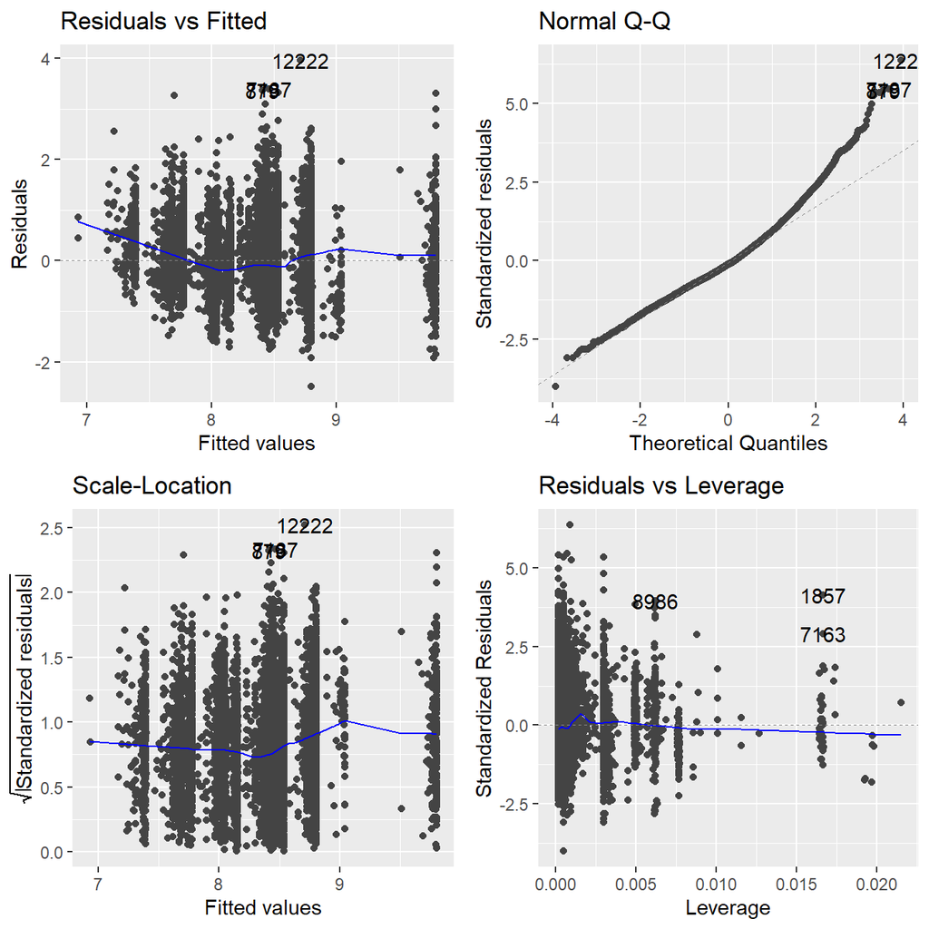

```r
autoplot(model3)
```

Model was also tested without number_of_reviews. There was almost no change in the R2 so number_of_reviews was taken out of the model, as review_scores rating explains more od the variability.

### Model 4: Adding accommodates to the model

```r
model4 <- lm(log (price_4_nights) ~ prop_type_simplified +
               review_scores_rating + room_type+
               accommodates, data= listings)

model4 %>%
  broom::tidy(conf.int=TRUE)%>%
  kable()%>%
  kable_styling()
```

| term | estimate | std.error | statistic | p.value | conf.low | conf.high |
| --- | --- | --- | --- | --- | --- | --- |
| (Intercept) | 7.439 | 0.053 | 141.134 | 0.000 | 7.335 | 7.542 |
| prop_type_simplifiedBed and breakfast | 0.174 | 0.040 | 4.391 | 0.000 | 0.096 | 0.252 |
| prop_type_simplifiedGuest suite | -0.245 | 0.018 | -13.626 | 0.000 | -0.280 | -0.210 |
| prop_type_simplifiedHouse | 0.022 | 0.014 | 1.496 | 0.135 | -0.007 | 0.050 |
| prop_type_simplifiedOther | 0.005 | 0.014 | 0.354 | 0.724 | -0.022 | 0.032 |
| prop_type_simplifiedVilla | 0.561 | 0.033 | 17.075 | 0.000 | 0.497 | 0.626 |
| review_scores_rating | 0.004 | 0.001 | 8.073 | 0.000 | 0.003 | 0.005 |
| room_typeHotel room | 0.094 | 0.043 | 2.167 | 0.030 | 0.009 | 0.180 |
| room_typePrivate room | -0.399 | 0.014 | -28.244 | 0.000 | -0.427 | -0.371 |
| room_typeShared room | -0.980 | 0.070 | -14.104 | 0.000 | -1.117 | -0.844 |
| accommodates | 0.180 | 0.003 | 63.319 | 0.000 | 0.174 | 0.185 |

```r
model4 %>%
  broom::glance()%>%
  kable()%>%
  kable_styling()
```

| r.squared | adj.r.squared | sigma | statistic | p.value | df | logLik | AIC | BIC | deviance | df.residual | nobs |
| --- | --- | --- | --- | --- | --- | --- | --- | --- | --- | --- | --- |
| 0.455 | 0.455 | 0.541 | 1034 | 0 | 10 | -9963 | 19949 | 20038 | 3622 | 12384 | 12395 |

### Model 5: Adding Air Conditioning

Since as stated earlier only 6% of the households in South Africa have air conditioning, we examine how significant it is in predicting the price.

```r
model5 <- lm(log (price_4_nights) ~ prop_type_simplified + review_scores_rating + room_type + accommodates + ac, data= listings)

model5 %>%
  broom::tidy(conf.int=TRUE)%>%
  kable()%>%
  kable_styling()
```

| term | estimate | std.error | statistic | p.value | conf.low | conf.high |
| --- | --- | --- | --- | --- | --- | --- |
| (Intercept) | 7.430 | 0.051 | 146.181 | 0.000 | 7.330 | 7.529 |
| prop_type_simplifiedBed and breakfast | 0.165 | 0.038 | 4.320 | 0.000 | 0.090 | 0.240 |
| prop_type_simplifiedGuest suite | -0.208 | 0.017 | -11.997 | 0.000 | -0.242 | -0.174 |
| prop_type_simplifiedHouse | 0.060 | 0.014 | 4.293 | 0.000 | 0.033 | 0.088 |
| prop_type_simplifiedOther | 0.001 | 0.013 | 0.051 | 0.959 | -0.025 | 0.027 |
| prop_type_simplifiedVilla | 0.531 | 0.032 | 16.745 | 0.000 | 0.469 | 0.593 |
| review_scores_rating | 0.004 | 0.001 | 7.028 | 0.000 | 0.003 | 0.005 |
| room_typeHotel room | 0.040 | 0.042 | 0.946 | 0.344 | -0.043 | 0.122 |
| room_typePrivate room | -0.379 | 0.014 | -27.765 | 0.000 | -0.405 | -0.352 |
| room_typeShared room | -0.932 | 0.067 | -13.905 | 0.000 | -1.064 | -0.801 |
| accommodates | 0.171 | 0.003 | 62.263 | 0.000 | 0.166 | 0.177 |
| acTRUE | 0.329 | 0.011 | 30.571 | 0.000 | 0.308 | 0.350 |

```r
model5 %>%
  broom::glance()%>%
  kable()%>%
  kable_styling()
```

| r.squared | adj.r.squared | sigma | statistic | p.value | df | logLik | AIC | BIC | deviance | df.residual | nobs |
| --- | --- | --- | --- | --- | --- | --- | --- | --- | --- | --- | --- |
| 0.493 | 0.493 | 0.521 | 1096 | 0 | 11 | -9512 | 19049 | 19146 | 3368 | 12383 | 12395 |

As was expected, A/C is a significant predictor of the cost for 4 nights as it has T-statistics >2 and p-vale <0.05! As predicted, if there is air conditioning in the property, it will be more expensive to rent.

### Model 6: Adding host_is_superhost

Now we examine if the hosts that are super_hosts would charge as more.

```r
model6 <- lm(log (price_4_nights) ~ prop_type_simplified + review_scores_rating + room_type + accommodates + ac + host_is_superhost, data= listings)

model6 %>%
  broom::tidy(conf.int=TRUE)%>%
  kable()%>%
  kable_styling()
```

| term | estimate | std.error | statistic | p.value | conf.low | conf.high |
| --- | --- | --- | --- | --- | --- | --- |
| (Intercept) | 7.402 | 0.051 | 144.135 | 0.000 | 7.301 | 7.502 |
| prop_type_simplifiedBed and breakfast | 0.163 | 0.038 | 4.275 | 0.000 | 0.088 | 0.238 |
| prop_type_simplifiedGuest suite | -0.202 | 0.017 | -11.582 | 0.000 | -0.236 | -0.168 |
| prop_type_simplifiedHouse | 0.060 | 0.014 | 4.297 | 0.000 | 0.033 | 0.088 |
| prop_type_simplifiedOther | 0.002 | 0.013 | 0.181 | 0.856 | -0.024 | 0.029 |
| prop_type_simplifiedVilla | 0.536 | 0.032 | 16.883 | 0.000 | 0.473 | 0.598 |
| review_scores_rating | 0.004 | 0.001 | 7.672 | 0.000 | 0.003 | 0.005 |
| room_typeHotel room | 0.038 | 0.042 | 0.900 | 0.368 | -0.045 | 0.120 |
| room_typePrivate room | -0.382 | 0.014 | -27.969 | 0.000 | -0.409 | -0.355 |
| room_typeShared room | -0.935 | 0.067 | -13.958 | 0.000 | -1.067 | -0.804 |
| accommodates | 0.171 | 0.003 | 62.042 | 0.000 | 0.166 | 0.176 |
| acTRUE | 0.332 | 0.011 | 30.780 | 0.000 | 0.311 | 0.353 |
| host_is_superhostTRUE | -0.039 | 0.010 | -3.714 | 0.000 | -0.059 | -0.018 |

```r
model6 %>%
  broom::glance()%>%
  kable()%>%
  kable_styling()
```

| r.squared | adj.r.squared | sigma | statistic | p.value | df | logLik | AIC | BIC | deviance | df.residual | nobs |
| --- | --- | --- | --- | --- | --- | --- | --- | --- | --- | --- | --- |
| 0.494 | 0.493 | 0.521 | 1006 | 0 | 12 | -9505 | 19038 | 19142 | 3364 | 12382 | 12395 |

While significant, whether or not the host is super host does not add to the explanation of the variability of the model.

### Model 7: Adding cancellation_policy

Now we examine if strict cancellation policy is an indicator of higher price.

```r
model7 <- lm(log (price_4_nights) ~ prop_type_simplified + review_scores_rating + room_type + accommodates + ac + cancellation_policy, data= listings)

model7 %>%
  broom::tidy(conf.int=TRUE)%>%
  kable()%>%
  kable_styling()
```

| term | estimate | std.error | statistic | p.value | conf.low | conf.high |
| --- | --- | --- | --- | --- | --- | --- |
| (Intercept) | 7.367 | 0.051 | 145.515 | 0.000 | 7.268 | 7.466 |
| prop_type_simplifiedBed and breakfast | 0.158 | 0.038 | 4.165 | 0.000 | 0.084 | 0.232 |
| prop_type_simplifiedGuest suite | -0.196 | 0.017 | -11.412 | 0.000 | -0.230 | -0.163 |
| prop_type_simplifiedHouse | 0.060 | 0.014 | 4.344 | 0.000 | 0.033 | 0.087 |
| prop_type_simplifiedOther | -0.001 | 0.013 | -0.069 | 0.945 | -0.027 | 0.025 |
| prop_type_simplifiedVilla | 0.518 | 0.031 | 16.484 | 0.000 | 0.456 | 0.579 |
| review_scores_rating | 0.004 | 0.001 | 6.905 | 0.000 | 0.003 | 0.005 |
| room_typeHotel room | 0.037 | 0.042 | 0.897 | 0.370 | -0.044 | 0.119 |
| room_typePrivate room | -0.366 | 0.014 | -26.949 | 0.000 | -0.392 | -0.339 |
| room_typeShared room | -0.915 | 0.066 | -13.785 | 0.000 | -1.046 | -0.785 |
| accommodates | 0.168 | 0.003 | 61.405 | 0.000 | 0.163 | 0.173 |
| acTRUE | 0.323 | 0.011 | 30.268 | 0.000 | 0.302 | 0.344 |
| cancellation_policymoderate | 0.039 | 0.012 | 3.210 | 0.001 | 0.015 | 0.063 |
| cancellation_policystrict | 0.168 | 0.011 | 14.605 | 0.000 | 0.145 | 0.190 |

```r
model7 %>%
  broom::glance()%>%
  kable()%>%
  kable_styling()
```

| r.squared | adj.r.squared | sigma | statistic | p.value | df | logLik | AIC | BIC | deviance | df.residual | nobs |
| --- | --- | --- | --- | --- | --- | --- | --- | --- | --- | --- | --- |
| 0.503 | 0.503 | 0.516 | 965 | 0 | 13 | -9388 | 18807 | 18918 | 3301 | 12381 | 12395 |

Similar to what we saw above, cancellation_policy is significant but explains very little in terms of the variability of the model.

### Model 8: Adding neighbourhood information

```r
model8 <- lm(log (price_4_nights) ~ prop_type_simplified + review_scores_rating + room_type + accommodates + ac+ neighbourhood_simplified, data= listings)

model8 %>%
  broom::tidy(conf.int=TRUE)%>%
  kable()%>%
  kable_styling()
```

| term | estimate | std.error | statistic | p.value | conf.low | conf.high |
| --- | --- | --- | --- | --- | --- | --- |
| (Intercept) | 7.563 | 0.050 | 152.278 | 0.000 | 7.465 | 7.660 |
| prop_type_simplifiedBed and breakfast | 0.203 | 0.037 | 5.443 | 0.000 | 0.130 | 0.275 |
| prop_type_simplifiedGuest suite | -0.156 | 0.017 | -9.149 | 0.000 | -0.189 | -0.122 |
| prop_type_simplifiedHouse | 0.076 | 0.014 | 5.586 | 0.000 | 0.050 | 0.103 |
| prop_type_simplifiedOther | 0.008 | 0.013 | 0.626 | 0.531 | -0.017 | 0.034 |
| prop_type_simplifiedVilla | 0.490 | 0.031 | 15.859 | 0.000 | 0.429 | 0.551 |
| review_scores_rating | 0.003 | 0.001 | 5.526 | 0.000 | 0.002 | 0.004 |
| room_typeHotel room | 0.031 | 0.041 | 0.755 | 0.450 | -0.049 | 0.111 |
| room_typePrivate room | -0.341 | 0.013 | -25.617 | 0.000 | -0.367 | -0.315 |
| room_typeShared room | -0.969 | 0.065 | -14.872 | 0.000 | -1.097 | -0.842 |
| accommodates | 0.175 | 0.003 | 65.185 | 0.000 | 0.170 | 0.180 |
| acTRUE | 0.315 | 0.011 | 29.879 | 0.000 | 0.294 | 0.335 |
| neighbourhood_simplifiedbetter | -0.181 | 0.014 | -13.061 | 0.000 | -0.208 | -0.154 |
| neighbourhood_simplifiedgood | -0.321 | 0.013 | -24.450 | 0.000 | -0.346 | -0.295 |
| neighbourhood_simplifiedstandard | -0.526 | 0.057 | -9.299 | 0.000 | -0.636 | -0.415 |

```r
model8 %>%
  broom::glance()%>%
  kable()%>%
  kable_styling()
```

| r.squared | adj.r.squared | sigma | statistic | p.value | df | logLik | AIC | BIC | deviance | df.residual | nobs |
| --- | --- | --- | --- | --- | --- | --- | --- | --- | --- | --- | --- |
| 0.522 | 0.521 | 0.507 | 964 | 0 | 14 | -9153 | 18338 | 18457 | 3178 | 12380 | 12395 |

The neighbourhood in which the property is located is a significant predictor of the price and adds around 3% in terms of R2 when all other explanaotry variables are considered.

Below, the interpretation of the final model coefficients is provided:

For 1 unit increase in review_scores_rating, there is an increase of **0.3%** in price_4_nights.

Price for 4 nights at a **Guest Suite** is on average ** **14.8% cheaper** than the price for an apartment.

## Summary table of final model and rationale

```r
#creating comparison table
huxreg(model1,model2, model3, model4, model5, model6, model7, model8,
       statistics = c('#observations' = 'nobs',
                      'R squared' = 'r.squared',
                      'Adj. R Squared' = 'adj.r.squared',
                      'Residual SE' = 'sigma'),
       bold_signif = 0.05,
       stars = NULL
) %>%
  set_caption('Comparison of models')
```

Comparison of models

|  | (1) | (2) | (3) | (4) | (5) | (6) | (7) | (8) |
| --- | --- | --- | --- | --- | --- | --- | --- | --- |
| (Intercept) | 8.391 | 8.467 | 8.086 | 7.439 | 7.430 | 7.402 | 7.367 | 7.563 |
|  | (0.009) | (0.008) | (0.059) | (0.053) | (0.051) | (0.051) | (0.051) | (0.050) |
| prop_type_simplifiedBed and breakfast | -0.058 | 0.360 | 0.371 | 0.174 | 0.165 | 0.163 | 0.158 | 0.203 |
|  | (0.032) | (0.034) | (0.045) | (0.040) | (0.038) | (0.038) | (0.038) | (0.037) |
| prop_type_simplifiedGuest suite | -0.393 | -0.272 | -0.292 | -0.245 | -0.208 | -0.202 | -0.196 | -0.156 |
|  | (0.022) | (0.021) | (0.021) | (0.018) | (0.017) | (0.017) | (0.017) | (0.017) |
| prop_type_simplifiedHouse | 0.053 | 0.291 | 0.355 | 0.022 | 0.060 | 0.060 | 0.060 | 0.076 |
|  | (0.015) | (0.015) | (0.015) | (0.014) | (0.014) | (0.014) | (0.014) | (0.014) |
| prop_type_simplifiedOther | 0.014 | 0.176 | 0.089 | 0.005 | 0.001 | 0.002 | -0.001 | 0.008 |
|  | (0.016) | (0.015) | (0.016) | (0.014) | (0.013) | (0.013) | (0.013) | (0.013) |
| prop_type_simplifiedVilla | 1.455 | 1.523 | 1.352 | 0.561 | 0.531 | 0.536 | 0.518 | 0.490 |
|  | (0.035) | (0.033) | (0.035) | (0.033) | (0.032) | (0.032) | (0.031) | (0.031) |
| room_typeHotel room |  | -0.084 | -0.047 | 0.094 | 0.040 | 0.038 | 0.037 | 0.031 |
|  |  | (0.040) | (0.050) | (0.043) | (0.042) | (0.042) | (0.042) | (0.041) |
| room_typePrivate room |  | -0.649 | -0.759 | -0.399 | -0.379 | -0.382 | -0.366 | -0.341 |
|  |  | (0.013) | (0.015) | (0.014) | (0.014) | (0.014) | (0.014) | (0.013) |
| room_typeShared room |  | -1.124 | -1.224 | -0.980 | -0.932 | -0.935 | -0.915 | -0.969 |
|  |  | (0.064) | (0.080) | (0.070) | (0.067) | (0.067) | (0.066) | (0.065) |
| review_scores_rating |  |  | 0.004 | 0.004 | 0.004 | 0.004 | 0.004 | 0.003 |
|  |  |  | (0.001) | (0.001) | (0.001) | (0.001) | (0.001) | (0.001) |
| accommodates |  |  |  | 0.180 | 0.171 | 0.171 | 0.168 | 0.175 |
|  |  |  |  | (0.003) | (0.003) | (0.003) | (0.003) | (0.003) |
| acTRUE |  |  |  |  | 0.329 | 0.332 | 0.323 | 0.315 |
|  |  |  |  |  | (0.011) | (0.011) | (0.011) | (0.011) |
| host_is_superhostTRUE |  |  |  |  |  | -0.039 |  |  |
|  |  |  |  |  |  | (0.010) |  |  |
| cancellation_policymoderate |  |  |  |  |  |  | 0.039 |  |
|  |  |  |  |  |  |  | (0.012) |  |
| cancellation_policystrict |  |  |  |  |  |  | 0.168 |  |
|  |  |  |  |  |  |  | (0.011) |  |
| neighbourhood_simplifiedbetter |  |  |  |  |  |  |  | -0.181 |
|  |  |  |  |  |  |  |  | (0.014) |
| neighbourhood_simplifiedgood |  |  |  |  |  |  |  | -0.321 |
|  |  |  |  |  |  |  |  | (0.013) |
| neighbourhood_simplifiedstandard |  |  |  |  |  |  |  | -0.526 |
|  |  |  |  |  |  |  |  | (0.057) |
| #observations | 17301 | 17301 | 12395 | 12395 | 12395 | 12395 | 12395 | 12395 |
| R squared | 0.112 | 0.231 | 0.278 | 0.455 | 0.493 | 0.494 | 0.503 | 0.522 |
| Adj. R Squared | 0.112 | 0.231 | 0.278 | 0.455 | 0.493 | 0.493 | 0.503 | 0.521 |
| Residual SE | 0.757 | 0.704 | 0.622 | 0.541 | 0.521 | 0.521 | 0.516 | 0.507 |

This table shows all of the coefficients and R squared of the models that were considered. The final model has the highest R2 out of the models that were considered.